# Effects of user type on bike usage

## Investigation Overview

In this investigation, I wanted to look at how the bike usage in Bay Area is affected by the type of users, whether they were customers or subscribers.

## Dataset Overview

The data consisted of duration of travel, start time, end time, start station, end station, start latitude and longitude, end latitude and longitude and some other characteristics like user tpe, rental access and bike share for all. I computed the distance using the haversine formula and added it to the dataset, to get a sense of the distance travelled. The dataset is for the month of November 2019.

# Distribution of duration

The distribution is unimodal with a long tail. The variable has most of its values around 1000. The maximum value is around 85000.

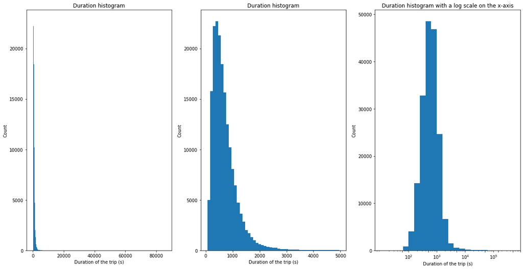

```python
plt.subplots(1,3,figsize=(20,10))
bins = np.arange(bike_data_copy['duration_sec'].min(),bike_data_copy['duration_sec'].max()+10,100)
plt.subplot(1,3,1)
plt.hist(data=bike_data_copy,x='duration_sec',bins=bins)
plt.xlabel('Duration of the trip (s)')
plt.ylabel('Count')
plt.title('Duration histogram')
plt.subplot(1,3,2)
bins=np.arange(60,5000,100)
plt.hist(data=bike_data_copy,x='duration_sec',bins=bins)
plt.xlabel('Duration of the trip (s)')
plt.ylabel('Count')
plt.title('Duration histogram')
plt.subplot(1,3,3)
# Looks like a long tail distribution.
# Trying out a log x-scale as the durations vary a great deal.
bins = 10**np.arange(1,5,0.2)
plt.hist(data=bike_data_copy,x='duration_sec',bins=bins)
plt.xscale('log')
plt.xticks([60,100,500,1000,5000,10000,50000,100000,150000,500000,900000])
plt.xlabel('Duration of the trip (s)')
plt.ylabel('Count')
plt.title('Duration histogram with a log scale on the x-axis')
```

# Distribution of distance

Distance also follow a similar distribution as the duration. The maximum value goes upto 9 mi but most of the trips are around the 1 mi distance.

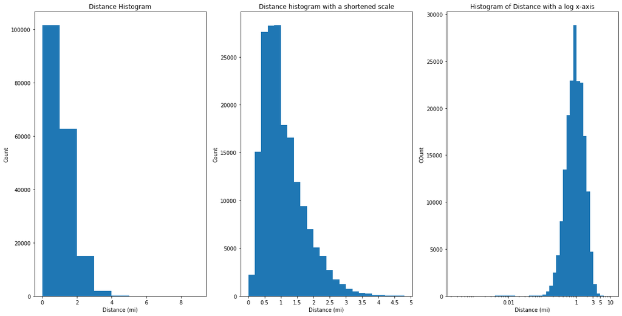

```python
plt.subplots(1,3,figsize=(20,10))
bins = np.arange(0,bike_data_copy['distance'].max()+0.2,1)
plt.subplot(1,3,1)
plt.hist(data=bike_data_copy,x='distance',bins=bins)
plt.xlabel('Distance (mi)')
plt.ylabel('Count')
plt.title('Distance Histogram')
plt.subplot(1,3,2)
bins=np.arange(0,5,0.2)
plt.hist(data=bike_data_copy,x='distance',bins=bins)
plt.xticks([0,0.5,1,1.5,2,2.5,3,3.5,4,4.5,5],['0','0.5','1','1.5','2','2.5','3','3.5','4','4.5','5']);
plt.xlabel('Distance (mi)')
plt.ylabel('Count')
plt.title('Distance histogram with a shortened scale')
plt.subplot(1,3,3)
bins = 10**np.arange(-3.6,1.1,0.1)
plt.hist(data=bike_data_copy,x='distance',bins=bins)
plt.xscale('log')
plt.xticks([0.01,1,3,5,10],[0.01,1,3,5,10])
plt.xlabel('Distance (mi)')
plt.ylabel('COunt')
plt.title('Histogram of Distance with a log x-axis')
```

# Distribution of users

Users are of two types- Subscribers and Customers. Subscribers far outnumber the customers.

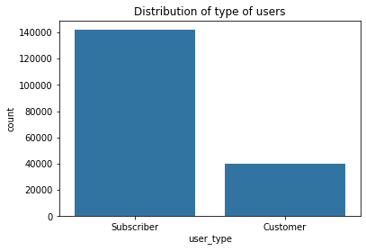

```python
base_color = sb.color_palette()[0]
sb.countplot(data=bike_data_copy,x='user_type',color=base_color)
# The subscribers far outnumber the customers.
plt.title('Distribution of type of users')
```

# Distance vs time

I assumed distance vs time to have a positive correlation and expected it to have a linear relationship. But, it had a relationship where distance peaked and fell after that. I assume it was because the person used to reach a destination and spend time there, eventually returning to their initial start point.

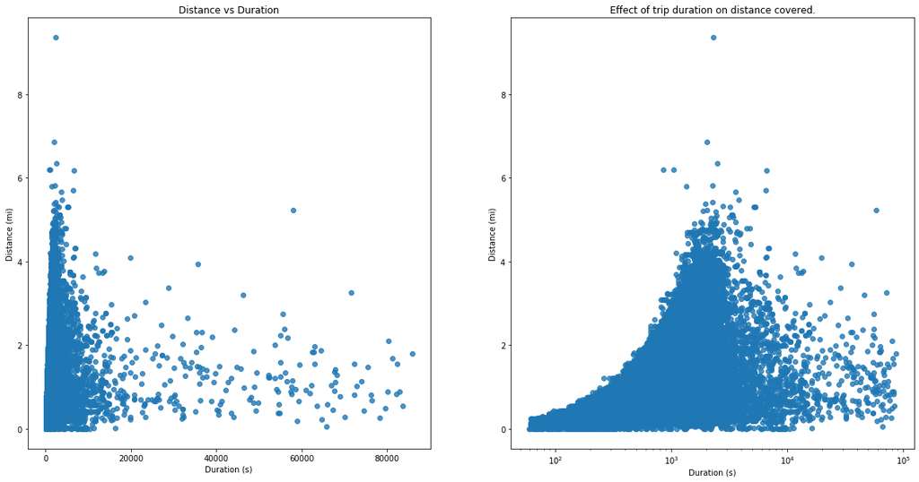

```python
plt.subplots(1,2,figsize=(20,10))
plt.subplot(1,2,1)
sb.regplot(data=bike_data_copy,x='duration_sec',y='distance',x_jitter=0.3,fit_reg=False)
plt.xlabel('Duration (s)')
plt.ylabel('Distance (mi)')
plt.title('Distance vs Duration')
# Since it has a long tail, a log plot will be appropriate.
plt.subplot(1,2,2)
ax=sb.regplot(data=bike_data_copy,x='duration_sec',y='distance',x_jitter=0.3,fit_reg=False)
plt.xlabel('Duration (s)')
plt.ylabel('Distance (mi)')
ax.set(xscale='log')
plt.title('Effect of trip duration on distance covered.')
```

# Impact of user type on distance and duration

```
user_type
Subscriber    1.046773
Customer      1.182795
Name: distance, dtype: float64
user_type
Subscriber     667.734891
Customer      1132.651264
Name: duration_sec, dtype: float64
```

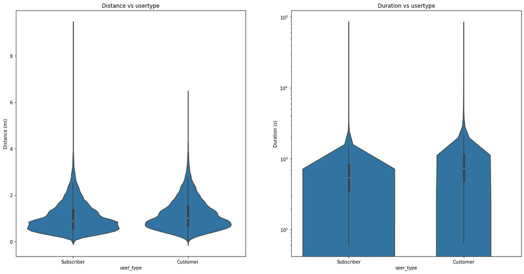

```python
#Let's check out the relationship between distance and user_type. As one is quantitative and the other qualitative,
# we wil use the boxplot.
print(bike_data_copy.groupby('user_type')['distance'].mean())
print(bike_data_copy.groupby('user_type')['duration_sec'].mean())
plt.subplots(1,2,figsize=(20,10))
plt.subplot(1,2,1)
sb.violinplot(data=bike_data_copy,x='user_type',y='distance',color=base_color)
plt.ylabel('Distance (mi)')
plt.title('Distance vs usertype')
plt.subplot(1,2,2)
sb.violinplot(data=bike_data_copy,x='user_type',y='duration_sec',color=base_color)
plt.yscale('log')
plt.ylabel('Duration (s)')
plt.title('Duration vs usertype')
```

# Impact of user type on station usage based on mean duration of trip

We were trying to see whether there is any overlap on station usage based on user type. We split the data into three types- one for distance < 1 mi, another between 1 and 2 mi and the third greater than 2 mi. I didn't see any overlap in the usage of stations furthering the divide between the two user types.

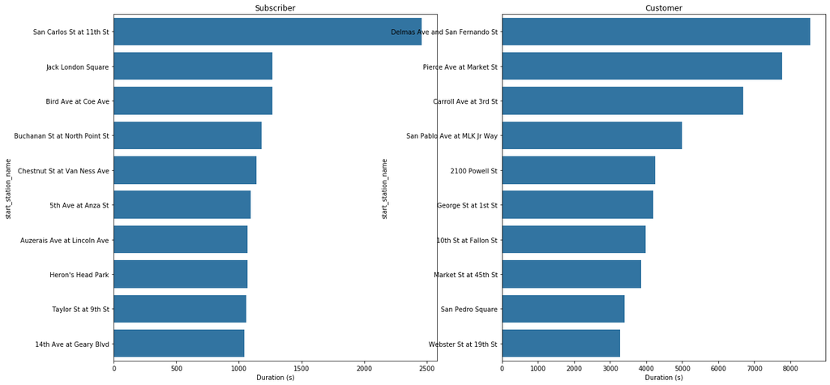

```python
# Let's check out a dataset with distance < 1 mi. Let's plot the popular start stations vs time with a facet based on the
# user_type
data_sub = bike_data_copy[bike_data_copy['distance']< 1]
order = ['Subscriber','Customer']
plt.subplots(1,2,figsize=(20,10))
for i,member in enumerate(order):
    plt.subplot(1,2,i+1)
    sub = data_sub[data_sub['user_type']==member]
    grouped_data = sub.groupby('start_station_name')['duration_sec'].mean().sort_values(ascending=False)
    #print(grouped_data)
    xval = grouped_data.index[:10]
    sb.barplot(grouped_data.values[:10],grouped_data.index[:10],color=base_color)
    plt.title(member)
    plt.xlabel('Duration (s)')
```

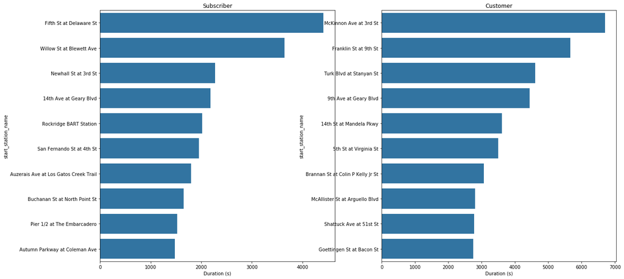

```python
# Let's do it for distances >= 1 and < 2
data_sub = bike_data_copy[(bike_data_copy['distance']>= 1) & (bike_data_copy['distance']<2)]
order = ['Subscriber','Customer']
plt.subplots(1,2,figsize=(20,10))
for i,member in enumerate(order):
    plt.subplot(1,2,i+1)
    sub = data_sub[data_sub['user_type']==member]
    grouped_data = sub.groupby('start_station_name')['duration_sec'].mean().sort_values(ascending=False)
    xval = grouped_data.index[:10]
    sb.barplot(grouped_data.values[:10],grouped_data.index[:10],color=base_color)
    plt.title(member)
    plt.xlabel('Duration (s)')
```

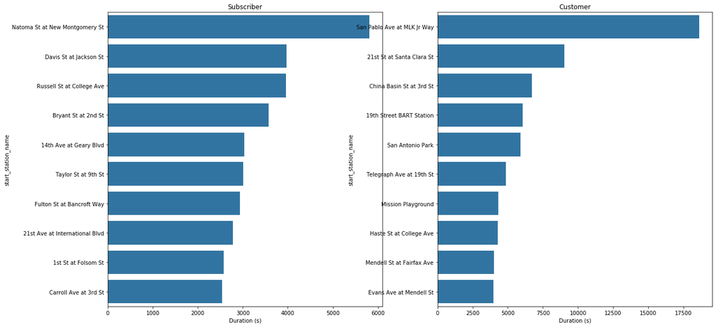

```python
# Finally, let's do it for distances above 2 mi.
data_sub = bike_data_copy[bike_data_copy['distance']>=2]
order = ['Subscriber','Customer']
plt.subplots(1,2,figsize=(20,10))
for i,member in enumerate(order):
    plt.subplot(1,2,i+1)
    sub = data_sub[data_sub['user_type']==member]
    grouped_data = sub.groupby('start_station_name')['duration_sec'].mean().sort_values(ascending=False)
    xval = grouped_data.index[:10]
    sb.barplot(grouped_data.values[:10],grouped_data.index[:10],color=base_color)
    plt.title(member)
    plt.xlabel('Duration (s)')
```